## 研究目的

BIRCH算法（Balanced Iterative Reducing and Clustering using Hierarchies）一次扫描能够产生一个基本聚类，多次扫描能够改善聚类结果。它是一个增量的聚类方法，对于数据的聚类决策是基于已经处理过的数据点，而不是全部样本空间，因此能够提高计算速度，所以它天生就是为处理大规模的数据集和数据流聚类而设计的。本文使用普通的层次聚类法与BIRCH算法作比较，观察两者在静态数据流和动态数据流聚类上的表现，凸显BIRCH算法在运行速度、在有标签和无标签两种情况上更优的聚类效果。

```r
library("stream")
setwd("E:/graduate/class/非结构化/数据流")
set.seed(1000)
stream <- DSD_Gaussians(k = 3, d = 2)#3 clusters in 2 dimensions
#DSD开头的都是随机数据流生成器
write_stream(stream,"./新建文件夹/stream.txt",n=8000) #随机生成数据流，写入文件
```

## 算法

#### 1. 层次聚类法

层次聚类法是传统的统计聚类分析方法之一。先计算样本之间的距离。每次将距离最近的点合并到同一个类。然后，再计算类与类之间的距离，将距离最近的类合并为一个大类。不停的合并，直到合成了一个类。其中类与类的距离的计算方法有：最短距离法，最长距离法，中间距离法，类平均法等。比如最短距离法，将类与类的距离定义为类与类之间样本的最短距离。

由于BIRCH算法是层次聚类方法的一种，两者的聚类思想有诸多相似之处，如两种方法均无需事先指定聚类个数，聚类个数可根据设定的阈值选取，因此选传统的层次聚类法与BIRCH算法作比较，查看两者对数据流的聚类效果。

## 评价标准

#### 1. 轮廓系数

轮廓系数（Silhouette Coefficient），是聚类效果好坏的一种评价标准，适用于实际类别信息未知的情况。最早由 Peter J. Rousseeuw 在 1986 提出。它结合内聚度和分离度两种因素。可以用来在相同原始数据的基础上用来评价不同算法、或者算法不同运行方式对聚类结果所产生的影响。其基本原理为：对于单个样本，设a是与它同类别中其他样本的平均距离，b是与它距离最近不同类别中样本的平均距离，其轮廓系数为：

$$s w_{i}=\frac{\left(b_{i}-a_{i}\right)}{\max \left(a_{i}, b_{i}\right)}$$

对于一个样本集合，它的轮廓系数是所有样本轮廓系数的平均值。

$$\overline{S W}=\frac{1}{n} \sum_{i=1}^{n} S W_{i}$$

轮廓系数的取值范围是[-1,1]，同类别样本距离越相近不同类别样本距离越远，分数越高。如果观测值的 $S W_{i}$ 值接近1，则这个数据点比邻近点更靠近自己的类；如果观测值的 $S W_{i}$ 值接近-1，则这个数据点没有被很好的聚类；如果观测值的 $S W_{i}$ 值接近0，则这个数据点可以归于当前的类或离这个数据点最近的一个类。Kaufman和Rousseeuw提出$\overline{S W}$ >0.5，则可以进行合理的聚类， $\overline{S W}$ <0.2时，则表示数据集不存在很好的聚类结构。

#### 2. 纯度

纯度（purity）是已知样本真实标签时极为简单的一种聚类评价方法，只需计算正确聚类的文档数占总文档数的比例。其中$X=\left\{\mathrm{x}_{1}, \mathrm{x}_{2}, \ldots, \mathrm{x}_{k}\right\}$ 是聚类的集合 $x_{i}$表示第i个聚类的集合。$Y=\left\{\mathrm{y}_{1}, \mathrm{y}_{2}, \ldots, \mathrm{y}_{r}\right\}$ 是真实标签集合， $y_{j}$表示第j个真实标签，N表示文档总数。

$$\text {purity}=\frac{1}{N} \sum_{k} \max \left|x_{i} \bigcap y_{j}\right|$$

## BIRCH算法在鸢尾花数据集的聚类分析

```r
data(iris)
head(iris)
```

```
##   Sepal.Length Sepal.Width Petal.Length Petal.Width Species
## 1          5.1         3.5          1.4         0.2  setosa
## 2          4.9         3.0          1.4         0.2  setosa
## 3          4.7         3.2          1.3         0.2  setosa
## 4          4.6         3.1          1.5         0.2  setosa
## 5          5.0         3.6          1.4         0.2  setosa
## 6          5.4         3.9          1.7         0.4  setosa
```

```r
unique(iris$Species)
```

```
## [1] setosa     versicolor virginica
## Levels: setosa versicolor virginica
```

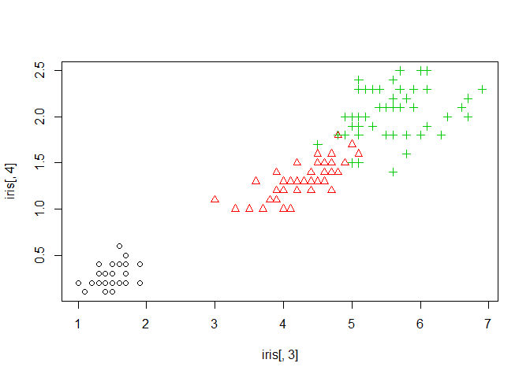

```r
plot(iris[,3],iris[,4],col=iris[,5],pch = c(1:3)[iris[,5]])
```

```r
iris2 = rbind(iris,iris)
replayer <- DSD_Memory(iris2[,c(3,4)], k = NA)
replayer
```

```
## Memory Stream Interface
## Class: DSD_Memory, DSD_R, DSD_data.frame, DSD
## With NA clusters in 2 dimensions
## Contains 300 data points - currently at position 1 - loop is FALSE
```

```r
# get_points(replayer, n = 5)
# plot(replayer)
# reset_stream(replayer, pos = 1)
# replayer
birch<- DSC_BIRCH(treshold = .65, branching = 8, maxLeaf = 20)
update(birch, replayer, n = 150)
birch
```

```
## BIRCH
## Class: DSC_BIRCH, DSC_Micro, DSC_R, DSC
## Number of micro-clusters: 3
```

```r
# reset_stream(replayer, pos = 1)
# get_points( replayer,n=150,class=T)
# plot(birch, replayer, n = 150)
evaluate(birch, replayer, measure=c("numMicro","numMacro","silhouette","purity"),n=150)
```

```
## Evaluation results for micro-clusters.
## Points were assigned to micro-clusters.
##
## numMicroClusters numMacroClusters       silhouette           purity
##        3.0000000               NA        0.6613248        1.0000000
```

```r
iris$cluster_label =factor(get_assignment(birch, get_points(replayer, n=150)))#
```

```
## Error in get_points.DSD_Memory(replayer, n = 150): The stream is at its end!
```

```r
mean(iris$cluster_label==c(1:3)[iris$Species])
```

```
## [1] NaN
```

```r
library(ggplot2)
ggplot(iris,aes(Petal.Length,Petal.Width,color = Species,shape = cluster_label))+geom_point(size = 2)
```

```
## Error in FUN(X[[i]], ...): 找不到对象'cluster_label'
```

#### 1. 基于静态数据流

```r
set.seed(1000)
stream <- DSD_Gaussians(k = 3, d = 2)#3 clusters in 2 dimensions
birch<- DSC_BIRCH(treshold = .18, branching = 8, maxLeaf = 20)
update(birch, stream, n = 500)
#update the model with the next 500 data points from the stream.
birch
```

```
## BIRCH
## Class: DSC_BIRCH, DSC_Micro, DSC_R, DSC
## Number of micro-clusters: 3
```

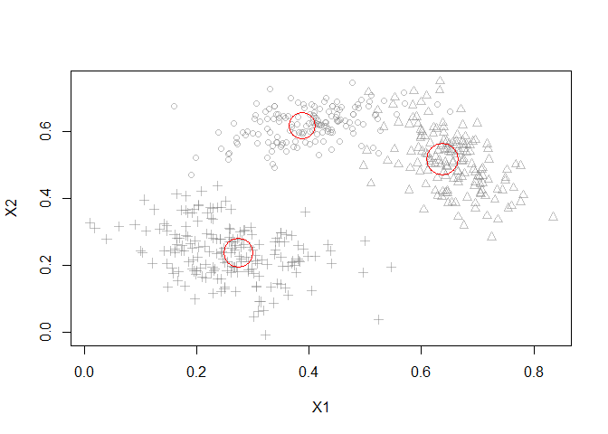

```r
plot(birch, stream)
```

```r
evaluate(birch, stream, measure=c("numMicro","numMacro","silhouette","purity"),n=500)
```

```
## Evaluation results for micro-clusters.
## Points were assigned to micro-clusters.
##
## numMicroClusters numMacroClusters       silhouette           purity
##        3.0000000               NA        0.5777850        0.9857663
```

```r
set.seed(1000)
stream <- DSD_Gaussians(k = 3, d = 2)#3 clusters in 2 dimensions
Hier<- DSC_Hierarchical(h=.65, method="complete")
update(Hier, stream, n = 500)
Hier
```

```
## Hierarchical (complete)
## Class: DSC_Hierarchical, DSC_Macro, DSC_R, DSC
## Number of micro-clusters: 500
## Number of macro-clusters: 3
```

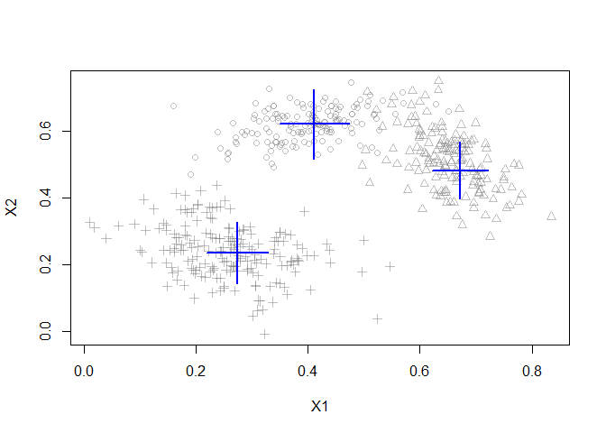

```r
plot(Hier, stream)
```

```r
evaluate(Hier, stream, measure=c("numMicro","numMacro","silhouette","purity"),n=500)
```

```
## Evaluation results for macro-clusters.
## Points were assigned to micro-clusters.
##
## numMicroClusters numMacroClusters       silhouette           purity
##      500.0000000        3.0000000        0.5613349        0.9747748
```

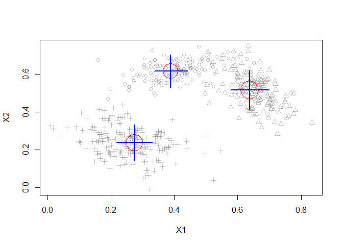

```r
#recluster
# Use a macro clustering algorithm to recluster micro-clusters into a final clustering.
set.seed(1000)
stream <- DSD_Gaussians(k = 3, d = 2)#3 clusters in 2 dimensions
birch<- DSC_BIRCH(treshold = .18, branching = 8, maxLeaf = 20)
update(birch, stream, n = 500)
Hier<- DSC_Hierarchical(h=.2, method="complete")
recluster(Hier,birch)
plot(Hier, stream, type = "both")
```

```r
evaluate(Hier, stream, measure=c("numMicro","numMacro","silhouette","purity"),n=500)
```

```
## Evaluation results for macro-clusters.
## Points were assigned to micro-clusters.
##
## numMicroClusters numMacroClusters       silhouette           purity
##        3.0000000        3.0000000        0.5777850        0.9857663
```

#### 2. 基于动态数据流

使用R语言stream包中的DSD_Gaussians函数随机生成25000条服从高斯分布的数据流样本，维数为2，中心点个数为3。每次取500条用BIRCH和层次聚类法分别进行聚类，记录轮廓系数和纯度。在50次聚类中，使用默认参数（BIRCH算法的阈值为0.1，层次聚类法的阈值为0.2）的两种算法聚类个数均为3类。

```r
df = data.frame()
set.seed(1000)
stream <- DSD_Gaussians(k = 3, d = 2)#3 clusters in 2 dimensions
birch<- DSC_BIRCH(treshold = .1, branching = 8, maxLeaf = 20) #
update(birch, stream, n = 500)
system.time(ev <- evaluate_cluster(birch, stream,
                       measure = c("numClasses","silhouette","purity"),
                       n = 25000, horizon = 500))
```

```
##    user  system elapsed
##    2.46    0.07    2.52
```

```r
head(ev)
```

```
##   points numClasses silhouette    purity
## 1      0          3  0.3382759 0.9791209
## 2    500          3  0.3404097 0.9853526
## 3   1000          3  0.3534809 0.9805862
## 4   1500          3  0.3537680 0.9788580
## 5   2000          3  0.3447878 0.9805195
## 6   2500          3  0.3551453 0.9886423
```

```r
# plot(ev[ , "points"], ev[ , "silhouette"], type = "l",ylab = "silhouette", xlab = "Points")
mean(ev[ , "silhouette"]);var(ev[ , "silhouette"])
```

```
## [1] 0.3595144
```

```
## [1] 0.0001239341
```

```r
mean(ev[ , "purity"]);var(ev[ , "purity"])
```

```
## [1] 0.9815909
```

```
## [1] 3.71675e-05
```

```r
df = rbind(df,ev)

set.seed(1000)
stream <- DSD_Gaussians(k = 3, d = 2)#3 clusters in 2 dimensions
Hier<- DSC_Hierarchical(h=.2, method="complete") #
update(Hier, stream, n = 500)
system.time(ev <- evaluate_cluster(Hier, stream,
                       measure = c("numClasses","silhouette","purity"),
                       n = 25000, horizon = 500))
```

```
##    user  system elapsed
##    5.06    0.29    5.36
```

```r
head(ev)
```

```
##   points numClasses silhouette    purity
## 1      0          3  0.2373001 0.9639525
## 2    500          3  0.1914912 0.9615222
## 3   1000          3  0.2139206 0.9368205
## 4   1500          3  0.2343138 0.9801120
## 5   2000          3  0.2459393 0.9356516
## 6   2500          3  0.2314910 0.9646525
```

```r
# plot(ev[ , "points"], ev[ , "silhouette"], type = "l",ylab = "silhouette", xlab = "Points")
mean(ev[ , "silhouette"]);var(ev[ , "silhouette"])
```

```
## [1] 0.2340645
```

```
## [1] 0.0004570264
```

```r
mean(ev[ , "purity"]);var(ev[ , "purity"])
```

```
## [1] 0.9613939
```

```
## [1] 0.0002395193
```

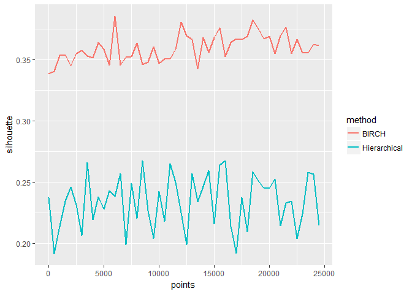

```r
df = rbind(df,ev)
df$method = c(rep("BIRCH",50),rep("Hierarchical",50))
library(ggplot2)
ggplot(df,aes(points,silhouette,color = method))+geom_line(size=1)
```

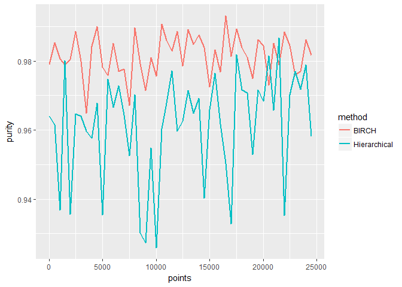

```r
ggplot(df,aes(points,purity,color = method))+geom_line(size=1)
```

## 结论

相比于传统的层次聚类法，BIRCH算法运行速度快，只需一遍扫描数据就可以有效地进行聚类，且聚类效果更好。但在调参方面，BIRCH要比层次聚类法复杂得多，因为它需要对CF Tree的几个关键的参数进行调参，这几个参数对CF Tree的最终形式影响很大。

## 参考

[1] Hahsler M , Matthew Bolan˜os. Introduction to stream: An Extensible Framework for Data Stream Clustering Research with R[J]. Journal of Statistical Software, 2017, 76(14).